# Sprawozdanie 1

Krzysztof Kotlarz

14 03 2020

# Lista 1.

## Zadanie 2.

```r
model.1 <- lm(dl.milk ~ sex + weight + ml.suppl + mat.weight + mat.height)
summary(model.1)
```

```
##
## Call:
## lm(formula = dl.milk ~ sex + weight + ml.suppl + mat.weight +
##     mat.height)
##
## Residuals:
##      Min       1Q   Median       3Q      Max
## -1.74201 -0.81173 -0.00926  0.78326  2.52646
##
## Coefficients:
##               Estimate Std. Error t value Pr(>|t|)
## (Intercept) -11.681839   4.361561  -2.678 0.010363 *
## sexgirl      -0.499532   0.312672  -1.598 0.117284
## weight        1.349124   0.322450   4.184 0.000135 ***
## ml.suppl     -0.002233   0.001241  -1.799 0.078829 .
## mat.weight    0.006212   0.023708   0.262 0.794535
## mat.height    0.072278   0.030169   2.396 0.020906 *
## ---
## Signif. codes:  0 '***' 0.001 '**' 0.01 '*' 0.05 '.' 0.1 ' ' 1
##
## Residual standard error: 1.075 on 44 degrees of freedom
## Multiple R-squared:  0.5459, Adjusted R-squared:  0.4943
## F-statistic: 10.58 on 5 and 44 DF,  p-value: 1.03e-06
```

### (a)

Zmienne istotne: *weight*, *mat.height*

### (b)

Zmienna *sex* jako factor ponieważ ta zmienna przyjmuje tylko 2 poziomy, jest to zmienna jakościowa.

### (c)

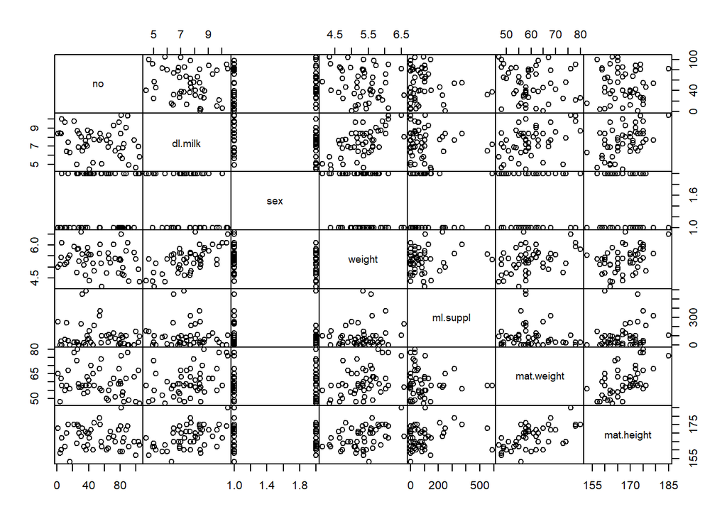

Wykres przedstawia korelacje zmiennych “każda z każdą”. Zauważono korelacje pomiedzy zmiennymi:

- *weight* <-> *dl.milk*
- *mat.weight* <-> *mat.height*

Wykonano macierz korelacji w celu potwierdzenia powyższych zależności:

```r
kfm.copy <- kfm
kfm.copy$sex <- as.numeric(kfm.copy$sex)
cor(kfm.copy)
```

```
##                     no     dl.milk         sex     weight    ml.suppl
## no          1.00000000 -0.18068364  0.06193530 -0.1649280 -0.12978958
## dl.milk    -0.18068364  1.00000000 -0.29940126  0.6360448 -0.06351955
## sex         0.06193530 -0.29940126  1.00000000 -0.2200106 -0.07136717
## weight     -0.16492803  0.63604482 -0.22001058  1.0000000  0.12838120
## ml.suppl   -0.12978958 -0.06351955 -0.07136717  0.1283812  1.00000000
## mat.weight -0.13731160  0.43427002 -0.05303191  0.4081748 -0.07887363
## mat.height -0.02356765  0.50504203 -0.11776734  0.3867571  0.18230263
##             mat.weight  mat.height
## no         -0.13731160 -0.02356765
## dl.milk     0.43427002  0.50504203
## sex        -0.05303191 -0.11776734
## weight      0.40817476  0.38675714
## ml.suppl   -0.07887363  0.18230263
## mat.weight  1.00000000  0.56473304
## mat.height  0.56473304  1.00000000
```

Z wykresu zależności parami jak i macierzy korelacji wynikają następujące silnie skorelowane pary:

- *weight* <-> *dl.milk*
- *mat.weight* <-> *mat.height*

### (d)

Przy poziomie istotności $\alpha$ = 5%

```r
model.all <- lm(dl.milk ~ ., data = kfm)
summary(model.all)
```

```
##
## Call:
## lm(formula = dl.milk ~ ., data = kfm)
##
## Residuals:
##      Min       1Q   Median       3Q      Max
## -1.89286 -0.87720  0.06426  0.73663  2.28685
##
## Coefficients:
##               Estimate Std. Error t value Pr(>|t|)
## (Intercept) -11.652909   4.357128  -2.674 0.010542 *
## no           -0.005522   0.005286  -1.045 0.302010
## sex2         -0.488757   0.312518  -1.564 0.125164
## weight        1.311822   0.324088   4.048 0.000212 ***
## ml.suppl     -0.002432   0.001254  -1.939 0.059077 .
## mat.weight    0.002453   0.023956   0.102 0.918925
## mat.height    0.076445   0.030401   2.515 0.015739 *
## ---
## Signif. codes:  0 '***' 0.001 '**' 0.01 '*' 0.05 '.' 0.1 ' ' 1
##
## Residual standard error: 1.074 on 43 degrees of freedom
## Multiple R-squared:  0.5571, Adjusted R-squared:  0.4953
## F-statistic: 9.015 on 6 and 43 DF,  p-value: 2.189e-06
```

Usunięto nieistotną zmienna *mat.weight*

```r
model.all_1 <- lm(dl.milk ~ no + sex + weight + ml.suppl + mat.height, data = kfm)
summary(model.all_1)
```

```
##
## Call:
## lm(formula = dl.milk ~ no + sex + weight + ml.suppl + mat.height,
##     data = kfm)
##
## Residuals:
##      Min       1Q   Median       3Q      Max
## -1.91656 -0.87688  0.05494  0.73957  2.28175
##
## Coefficients:
##               Estimate Std. Error t value Pr(>|t|)
## (Intercept) -11.818720   3.999250  -2.955 0.005004 **
## no           -0.005604   0.005167  -1.084 0.284057
## sex2         -0.486724   0.308359  -1.578 0.121630
## weight        1.320304   0.309779   4.262 0.000105 ***
## ml.suppl     -0.002466   0.001196  -2.061 0.045201 *
## mat.height    0.078083   0.025559   3.055 0.003815 **
## ---
## Signif. codes:  0 '***' 0.001 '**' 0.01 '*' 0.05 '.' 0.1 ' ' 1
##
## Residual standard error: 1.062 on 44 degrees of freedom
## Multiple R-squared:  0.557,  Adjusted R-squared:  0.5067
## F-statistic: 11.06 on 5 and 44 DF,  p-value: 6.137e-07
```

Usunięto nieistotną zmienną *no*

```r
model.all_2 <- lm(dl.milk ~ sex + weight + ml.suppl + mat.height, data = kfm)
summary(model.all_2)
```

```
##
## Call:
## lm(formula = dl.milk ~ sex + weight + ml.suppl + mat.height,
##     data = kfm)
##
## Residuals:
##      Min       1Q   Median       3Q      Max
## -1.77312 -0.81196 -0.00683  0.76988  2.52240
##
## Coefficients:
##               Estimate Std. Error t value Pr(>|t|)
## (Intercept) -12.112571   3.997860  -3.030  0.00405 **
## sex2         -0.494675   0.308875  -1.602  0.11626
## weight        1.372524   0.306612   4.476 5.14e-05 ***
## ml.suppl     -0.002313   0.001190  -1.943  0.05824 .
## mat.height    0.076363   0.025560   2.988  0.00454 **
## ---
## Signif. codes:  0 '***' 0.001 '**' 0.01 '*' 0.05 '.' 0.1 ' ' 1
##
## Residual standard error: 1.064 on 45 degrees of freedom
## Multiple R-squared:  0.5452, Adjusted R-squared:  0.5047
## F-statistic: 13.48 on 4 and 45 DF,  p-value: 2.658e-07
```

```r
model.all_3 <- lm(dl.milk ~ weight + ml.suppl + mat.height, data = kfm)
summary(model.all_3)
```

```
##
## Call:
## lm(formula = dl.milk ~ weight + ml.suppl + mat.height, data = kfm)
##
## Residuals:
##      Min       1Q   Median       3Q      Max
## -2.06540 -0.74758 -0.02408  0.67488  2.79882
##
## Coefficients:
##               Estimate Std. Error t value Pr(>|t|)
## (Intercept) -13.064926   4.020073  -3.250  0.00216 **
## weight        1.464781   0.306231   4.783 1.81e-05 ***
## ml.suppl     -0.002237   0.001209  -1.850  0.07074 .
## mat.height    0.077600   0.025979   2.987  0.00451 **
## ---
## Signif. codes:  0 '***' 0.001 '**' 0.01 '*' 0.05 '.' 0.1 ' ' 1
##
## Residual standard error: 1.082 on 46 degrees of freedom
## Multiple R-squared:  0.5192, Adjusted R-squared:  0.4879
## F-statistic: 16.56 on 3 and 46 DF,  p-value: 1.953e-07
```

```r
model.all_4 <- lm(dl.milk ~ weight + mat.height, data = kfm)
summary(model.all_4)
```

```
##
## Call:
## lm(formula = dl.milk ~ weight + mat.height, data = kfm)
##
## Residuals:
##      Min       1Q   Median       3Q      Max
## -2.19598 -0.82149  0.01822  0.75582  2.83375
##
## Coefficients:
##              Estimate Std. Error t value Pr(>|t|)
## (Intercept) -11.92014    4.07325  -2.926  0.00527 **
## weight        1.42862    0.31338   4.559 3.67e-05 ***
## mat.height    0.07063    0.02636   2.680  0.01013 *
## ---
## Signif. codes:  0 '***' 0.001 '**' 0.01 '*' 0.05 '.' 0.1 ' ' 1
##
## Residual standard error: 1.109 on 47 degrees of freedom
## Multiple R-squared:  0.4835, Adjusted R-squared:  0.4615
## F-statistic:    22 on 2 and 47 DF,  p-value: 1.811e-07
```

Usunięto nieistotną zmienną *ml.supply*. Ostateczny model:

$dl.milk = weight * 1.43 + mat.height * 0.07 - 11.92$

## Zadanie 2.

### (a)

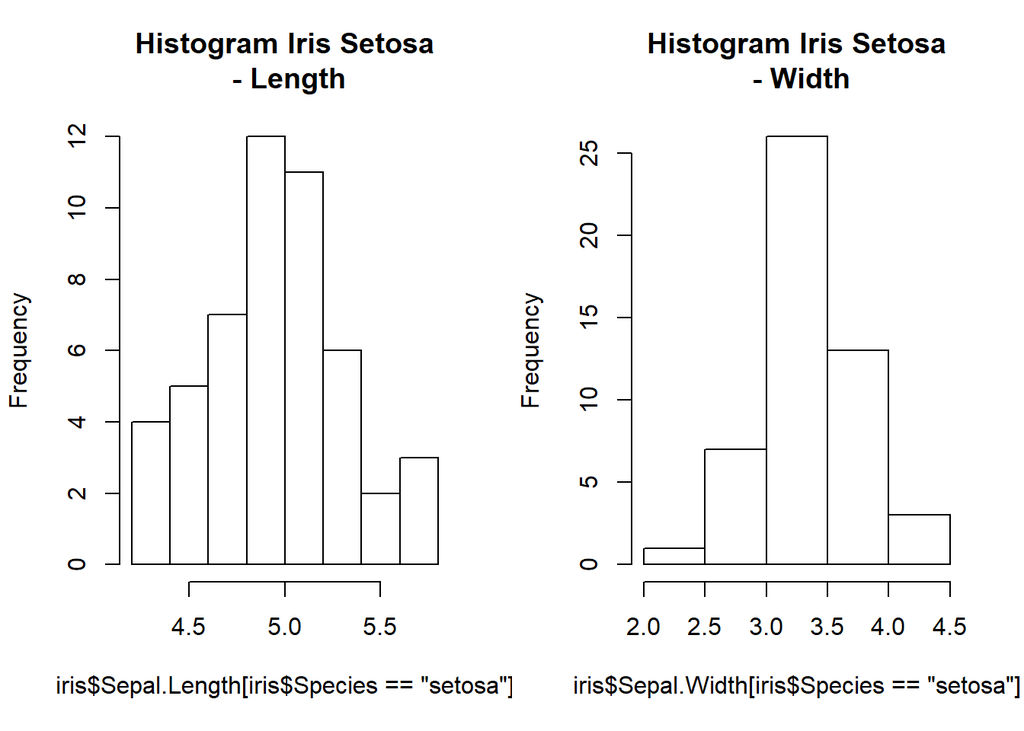

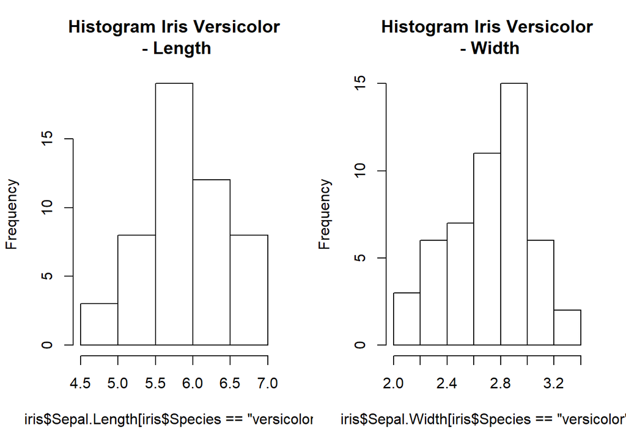

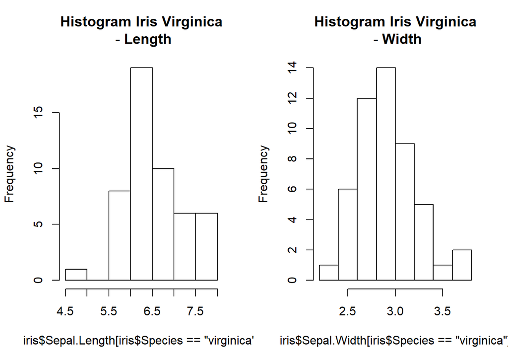

### (b)

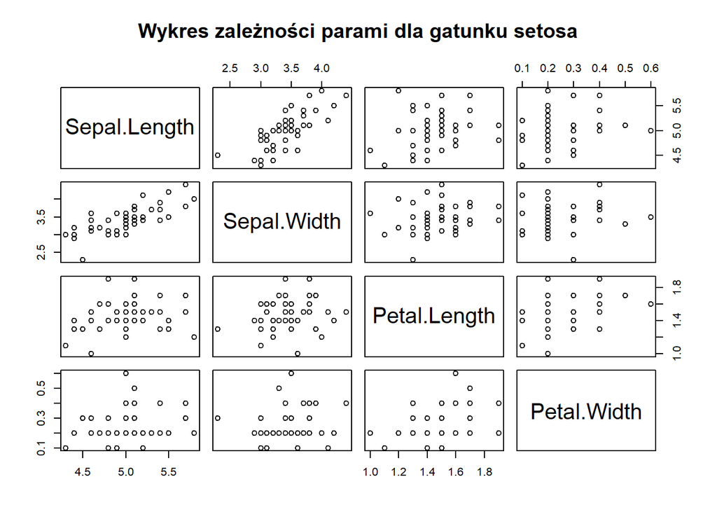

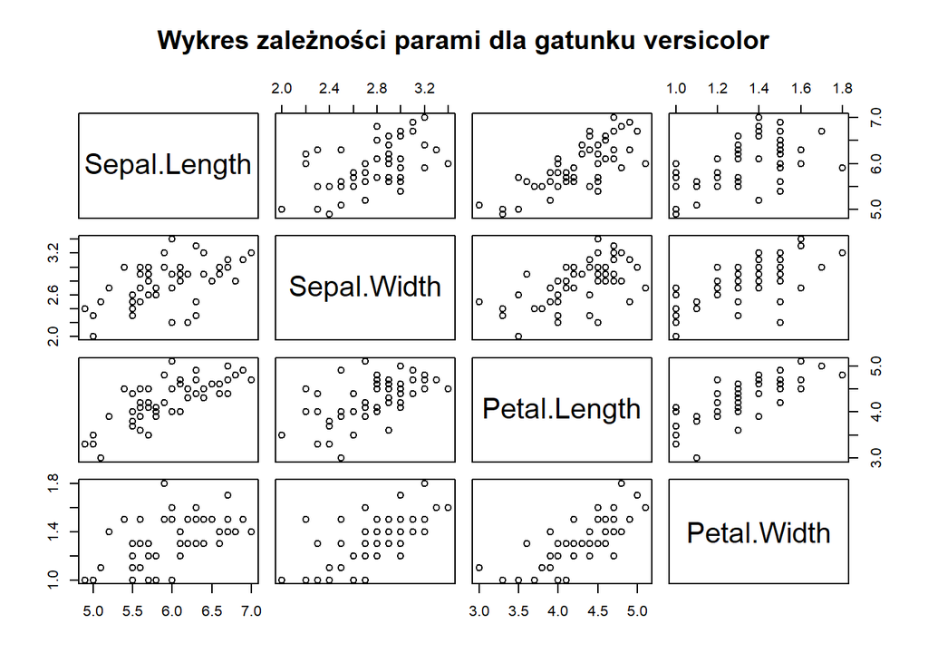

Korelacja pomiędzy zmiennymi *Sepal.Length* <-> *Petal.Length* oraz *Sepal.Width* <-> *Petal.Length*

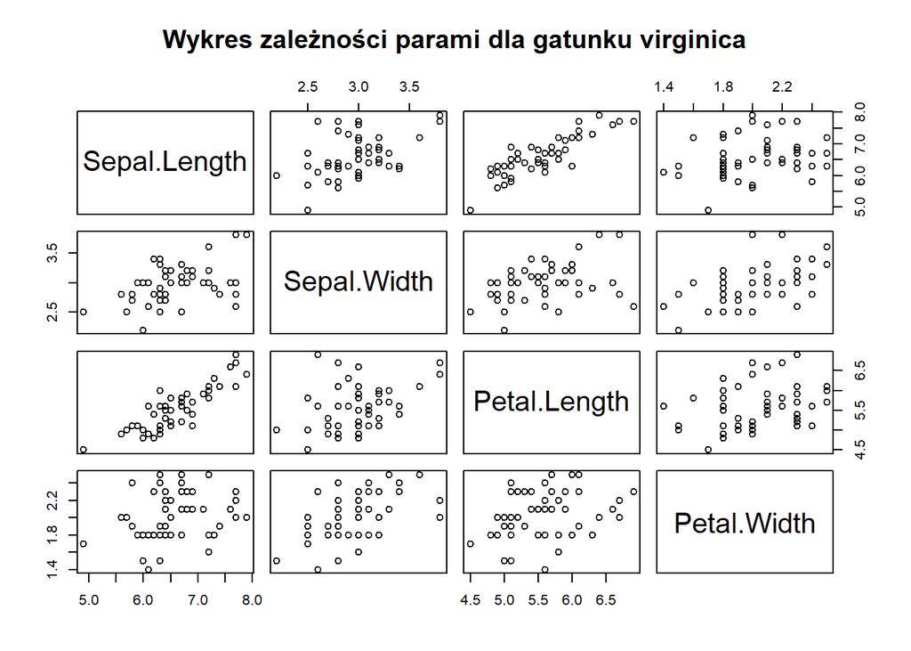

Silna korelacja pomiędzy zmiennymi *Sepal.Length* <-> *Petal.Length*

### (c)

```r
cor(iris[iris$Species=='setosa',c(1,3)])
```

```
##              Sepal.Length Petal.Length
## Sepal.Length    1.0000000    0.2671758
## Petal.Length    0.2671758    1.0000000
```

Słaba korelacja *Sepal.Length* <-> *Petal.Length* (0.26)

```r
cor(iris[iris$Species=='versicolor',c(1,3)])
```

```
##              Sepal.Length Petal.Length
## Sepal.Length     1.000000     0.754049
## Petal.Length     0.754049     1.000000
```

Silna korelacja *Sepal.Length* <-> *Petal.Length*(0.75)

```r
cor(iris[iris$Species=='virginica',c(1,3)])
```

```
##              Sepal.Length Petal.Length
## Sepal.Length    1.0000000    0.8642247
## Petal.Length    0.8642247    1.0000000
```

Silna korelacja *Sepal.Length* <-> *Petal.Length* (0.86)

```r
cor.test(iris$Sepal.Length[iris$Species == 'setosa'], iris$Petal.Length[iris$Species ==
                                                                          'setosa'])
```

```
##
##  Pearson's product-moment correlation
##
## data:  iris$Sepal.Length[iris$Species == "setosa"] and iris$Petal.Length[iris$Species == "setosa"]
## t = 1.9209, df = 48, p-value = 0.0607
## alternative hypothesis: true correlation is not equal to 0
## 95 percent confidence interval:
##  -0.01206954  0.50776233
## sample estimates:
##       cor
## 0.2671758
```

Współczynnik korelacji *Sepal.Length* i *Petal.Lengt* o wartości 0.27 gatunku *setosa* nie jest istotny na poziomie ostotności $\alpha$ = 5%

```r
cor.test(iris$Sepal.Length[iris$Species == 'versicolor'], iris$Petal.Length[iris$Species ==
                                                                              'versicolor'])
```

```
##
##  Pearson's product-moment correlation
##
## data:  iris$Sepal.Length[iris$Species == "versicolor"] and iris$Petal.Length[iris$Species == "versicolor"]
## t = 7.9538, df = 48, p-value = 2.586e-10
## alternative hypothesis: true correlation is not equal to 0
## 95 percent confidence interval:
##  0.6020680 0.8532995
## sample estimates:
##      cor
## 0.754049
```

Zmienne *Sepal.Length* i *Petal.Length* gatunku *versicolor* są istotnie skorelowane ze współczynnikiem korelacji na poziomie 0.75 i wartością p 2.586e-10

```r
cor.test(iris$Sepal.Length[iris$Species == 'virginica'], iris$Petal.Length[iris$Species ==
                                                                             'virginica'])
```

```
##
##  Pearson's product-moment correlation
##
## data:  iris$Sepal.Length[iris$Species == "virginica"] and iris$Petal.Length[iris$Species == "virginica"]
## t = 11.901, df = 48, p-value = 6.298e-16
## alternative hypothesis: true correlation is not equal to 0
## 95 percent confidence interval:
##  0.7714542 0.9210172
## sample estimates:
##       cor
## 0.8642247
```

Zmienne Sepal.Length i Petal.Lengt gatunku *virginica* są istotnie skorelowane ze współczynnikiem korelacji na poziomie 0.86 i wartością p 6.298e-16

```r
cor(iris[iris$Species=='setosa',1:4])
```

```
##              Sepal.Length Sepal.Width Petal.Length Petal.Width
## Sepal.Length    1.0000000   0.7425467    0.2671758   0.2780984
## Sepal.Width     0.7425467   1.0000000    0.1777000   0.2327520
## Petal.Length    0.2671758   0.1777000    1.0000000   0.3316300
## Petal.Width     0.2780984   0.2327520    0.3316300   1.0000000
```

```r
cor(iris[iris$Species=='versicolor',1:4])
```

```
##              Sepal.Length Sepal.Width Petal.Length Petal.Width
## Sepal.Length    1.0000000   0.5259107    0.7540490   0.5464611
## Sepal.Width     0.5259107   1.0000000    0.5605221   0.6639987
## Petal.Length    0.7540490   0.5605221    1.0000000   0.7866681
## Petal.Width     0.5464611   0.6639987    0.7866681   1.0000000
```

Dla gatunku *versicolor* najsilniej skorelowane są zmienne *Petal.Length* <-> *Petal.Width*

```r
cor(iris[iris$Species=='virginica',1:4])
```

```
##              Sepal.Length Sepal.Width Petal.Length Petal.Width
## Sepal.Length    1.0000000   0.4572278    0.8642247   0.2811077
## Sepal.Width     0.4572278   1.0000000    0.4010446   0.5377280
## Petal.Length    0.8642247   0.4010446    1.0000000   0.3221082
## Petal.Width     0.2811077   0.5377280    0.3221082   1.0000000
```

Dla gatunku *virginica* najsilniej skorelowane są zmienne *Petal.Length* <-> *Sepal.Length*

### (d)

```r
iris.setosa <- iris[iris$Species=='setosa',1:4]
```

```r
attach(iris.setosa)
model.all <- lm(Petal.Length ~ Sepal.Length + Sepal.Width + Petal.Width, data = iris.setosa)
summary(model.all)
```

```
##
## Call:
## lm(formula = Petal.Length ~ Sepal.Length + Sepal.Width + Petal.Width,
##     data = iris.setosa)
##
## Residuals:
##      Min       1Q   Median       3Q      Max
## -0.38868 -0.07905  0.00632  0.10095  0.48238
##
## Coefficients:
##              Estimate Std. Error t value Pr(>|t|)
## (Intercept)   0.86547    0.34331   2.521   0.0152 *
## Sepal.Length  0.11606    0.10162   1.142   0.2594
## Sepal.Width  -0.02865    0.09334  -0.307   0.7602
## Petal.Width   0.46253    0.23410   1.976   0.0542 .
## ---
## Signif. codes:  0 '***' 0.001 '**' 0.01 '*' 0.05 '.' 0.1 ' ' 1
##
## Residual standard error: 0.1657 on 46 degrees of freedom
## Multiple R-squared:  0.1449, Adjusted R-squared:  0.08914
## F-statistic: 2.598 on 3 and 46 DF,  p-value: 0.06356
```

```r
model.1 <- lm(Petal.Length ~ Sepal.Length + Petal.Width, data = iris.setosa)
summary(model.1)
```

```
##
## Call:
## lm(formula = Petal.Length ~ Sepal.Length + Petal.Width, data = iris.setosa)
##
## Residuals:
##      Min       1Q   Median       3Q      Max
## -0.40293 -0.08425  0.00073  0.09455  0.47839
##
## Coefficients:
##              Estimate Std. Error t value Pr(>|t|)
## (Intercept)   0.88128    0.33614   2.622   0.0117 *
## Sepal.Length  0.09342    0.06925   1.349   0.1838
## Petal.Width   0.45959    0.23164   1.984   0.0531 .
## ---
## Signif. codes:  0 '***' 0.001 '**' 0.01 '*' 0.05 '.' 0.1 ' ' 1
##
## Residual standard error: 0.1641 on 47 degrees of freedom
## Multiple R-squared:  0.1432, Adjusted R-squared:  0.1067
## F-statistic: 3.926 on 2 and 47 DF,  p-value: 0.0265
```

```r
model.2 <- lm(Petal.Length ~ Petal.Width, data = iris.setosa)
summary(model.2)
```

```
##
## Call:
## lm(formula = Petal.Length ~ Petal.Width, data = iris.setosa)
##
## Residuals:
##      Min       1Q   Median       3Q      Max
## -0.43686 -0.09151 -0.03686  0.09018  0.46314
##
## Coefficients:
##             Estimate Std. Error t value Pr(>|t|)
## (Intercept)  1.32756    0.05996  22.141   <2e-16 ***
## Petal.Width  0.54649    0.22439   2.435   0.0186 *
## ---
## Signif. codes:  0 '***' 0.001 '**' 0.01 '*' 0.05 '.' 0.1 ' ' 1
##
## Residual standard error: 0.1655 on 48 degrees of freedom
## Multiple R-squared:   0.11,  Adjusted R-squared:  0.09144
## F-statistic: 5.931 on 1 and 48 DF,  p-value: 0.01864
```

$Petal.Length = Petal.Width * 0.54 + 1.33$

- Przy wzroście wartości Petal.Width o 1, zmienna Petal.Length wzrośnie o 0.54
- Punkt przecięcia osi OY 1.33

# Lista 2.

## Zadanie 3.

```r
model.1 <- lm(stack.loss ~ Water.Temp + Acid.Conc.)
summary(model.1)
```

```
##
## Call:
## lm(formula = stack.loss ~ Water.Temp + Acid.Conc.)
##
## Residuals:
##     Min      1Q  Median      3Q     Max
## -7.8197 -2.8600 -0.6656  3.1235  8.3295
##
## Coefficients:
##             Estimate Std. Error t value Pr(>|t|)
## (Intercept) -51.2361    18.5374  -2.764   0.0128 *
## Water.Temp    2.7320     0.3949   6.919 1.82e-06 ***
## Acid.Conc.    0.1290     0.2329   0.554   0.5866
## ---
## Signif. codes:  0 '***' 0.001 '**' 0.01 '*' 0.05 '.' 0.1 ' ' 1
##
## Residual standard error: 5.137 on 18 degrees of freedom
## Multiple R-squared:  0.7704, Adjusted R-squared:  0.7449
## F-statistic:  30.2 on 2 and 18 DF,  p-value: 1.772e-06
```

W modelu powinna się znaleźć jedynie zmienna *Water.Temp*, zmienna *Acid.Conc.* jest nieisttona na poziomie a 5%

```r
model.2 <- lm(stack.loss ~ Water.Temp)
summary(model.2)
```

```
##
## Call:
## lm(formula = stack.loss ~ Water.Temp)
##
## Residuals:
##     Min      1Q  Median      3Q     Max
## -7.8904 -3.6206  0.3794  2.8398  8.4747
##
## Coefficients:
##             Estimate Std. Error t value Pr(>|t|)
## (Intercept) -41.9109     7.6056  -5.511 2.58e-05 ***
## Water.Temp    2.8174     0.3567   7.898 2.03e-07 ***
## ---
## Signif. codes:  0 '***' 0.001 '**' 0.01 '*' 0.05 '.' 0.1 ' ' 1
##
## Residual standard error: 5.043 on 19 degrees of freedom
## Multiple R-squared:  0.7665, Adjusted R-squared:  0.7542
## F-statistic: 62.37 on 1 and 19 DF,  p-value: 2.028e-07
```

Po usunięciu nieostotnej zmiennej, wyraz wolny zyskał wyższą istotność. Współczynnik dopasowania R2 = 0.75

### (ii)

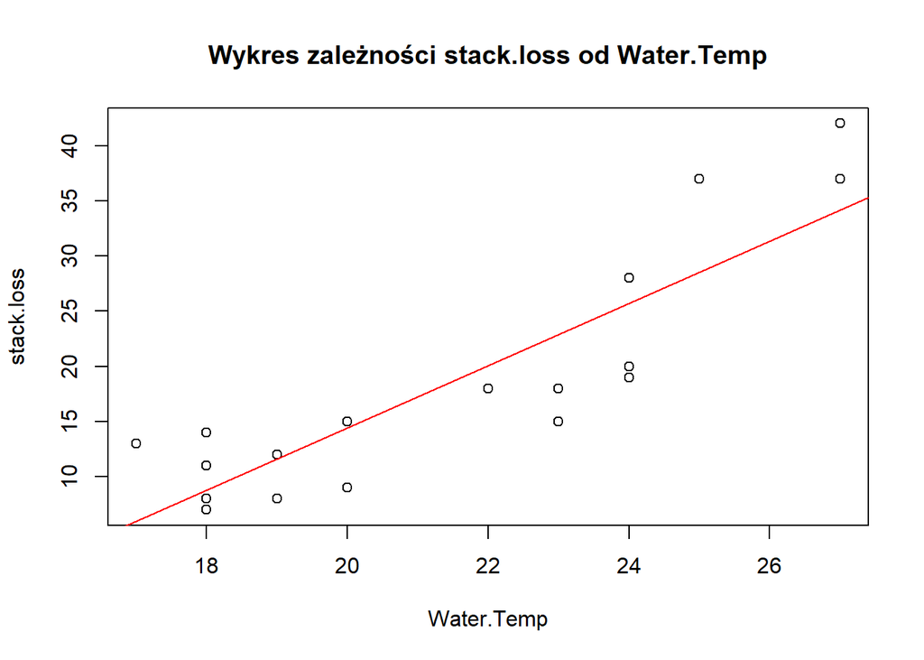

### (v, vi)

```r
reszty.stud <- rstudent(model.2)
outlier <- reszty.stud[abs(reszty.stud) > 2]
```

Brak obserwacji odstających wyznaczonych za pomocą reszt studentyzowanych dla rstudent > 2.

### (vii)

```r
outlierTest(model.2)
```

```
## No Studentized residuals with Bonferroni p < 0.05
## Largest |rstudent|:
##   rstudent unadjusted p-value Bonferroni p
## 3 1.917911           0.071129           NA
```

outlierTest nie również nie wykrywa obserwacji odstających na poziomie 5%

### (viii)

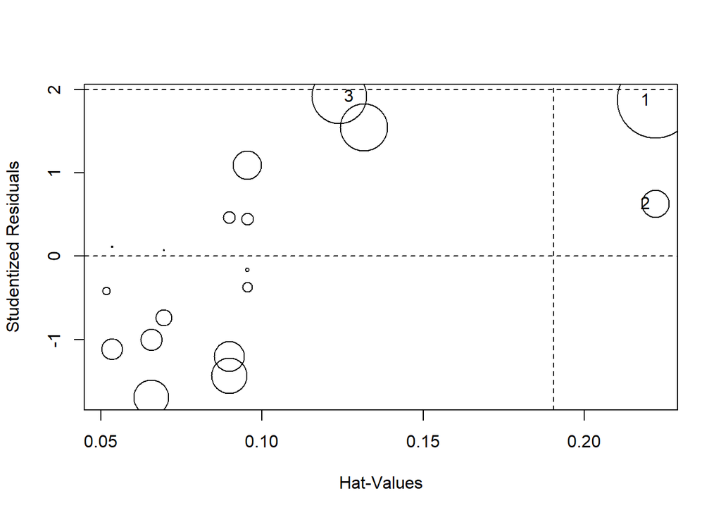

|  | StudRes | Hat | CookD |
| --- | --- | --- | --- |
| 1 | 1.8759536 | 0.2221163 | 0.44361619 |
| 2 | 0.6282651 | 0.2221163 | 0.05820793 |
| 3 | 1.9179109 | 0.1239276 | 0.22802446 |

```r
influencePlot(model.2)
```

influencePlot wskazuje dla CoocD = n/21 = 0.19: obserwacje 1 i 3

### (x)

```
## Influence measures of
##   lm(formula = stack.loss ~ Water.Temp) :
##
##     dfb.1_ dfb.Wt.T   dffit cov.r   cook.d    hat inf
## 1  -0.8120  0.88850  1.0024 1.002 0.443616 0.2221   *
## 2  -0.2719  0.29756  0.3357 1.372 0.058208 0.2221   *
## 3  -0.4954  0.56604  0.7213 0.877 0.228024 0.1239
## 4  -0.0840  0.10049  0.1466 1.195 0.011205 0.0898
## 5   0.0135 -0.02713 -0.0964 1.153 0.004859 0.0517
## 6   0.1057 -0.13991 -0.2663 1.070 0.035440 0.0658
## 7   0.2579 -0.30853 -0.4500 0.986 0.095958 0.0898
## 8   0.2161 -0.25850 -0.3771 1.050 0.069480 0.0898
## 9   0.1787 -0.23659 -0.4503 0.886 0.092259 0.0658
## 10  0.2842 -0.25073  0.3540 1.084 0.062041 0.0956
## 11  0.2842 -0.25073  0.3540 1.084 0.062041 0.0956
## 12  0.5280 -0.48072  0.6018 1.000 0.168744 0.1316
## 13  0.1170 -0.10323  0.1457 1.205 0.011087 0.0956
## 14  0.0140 -0.01167  0.0208 1.197 0.000228 0.0696
## 15 -0.0426  0.03756 -0.0530 1.228 0.001482 0.0956
## 16 -0.0959  0.08458 -0.1194 1.214 0.007469 0.0956
## 17 -0.1359  0.11299 -0.2011 1.129 0.020720 0.0696
## 18 -0.1359  0.11299 -0.2011 1.129 0.020720 0.0696
## 19 -0.1241  0.08886 -0.2656 1.030 0.034813 0.0536
## 20  0.0124 -0.00888  0.0265 1.176 0.000372 0.0536
## 21  0.0124 -0.00888  0.0265 1.176 0.000372 0.0536
```

Influence measures wskazuje obserwacje 1 oraz 2 jako wpływowe. Po porównaniu wyników z influencePlot wybrano oberwacje 1 jako wpływową.

### (xi)

```r
inf.ommit <- stackloss[-c(1),]
model.3 <- lm(inf.ommit$stack.loss~inf.ommit$Water.Temp)
```

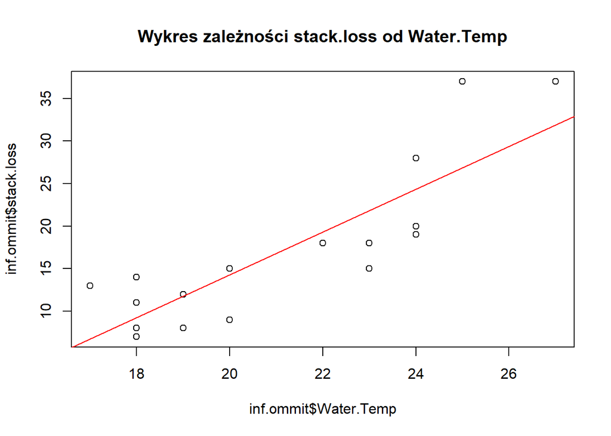

```r
plot(inf.ommit$stack.loss~inf.ommit$Water.Temp, main = 'Wykres zależności stack.loss od Water.Temp')
abline(model.3, col= 'red')
```

```r
summary(model.3)
```

```
##
## Call:
## lm(formula = inf.ommit$stack.loss ~ inf.ommit$Water.Temp)
##
## Residuals:
##     Min      1Q  Median      3Q     Max
## -6.8431 -3.7843 -0.5049  3.9167 10.1176
##
## Coefficients:
##                      Estimate Std. Error t value Pr(>|t|)
## (Intercept)          -36.1078     7.7873  -4.637 0.000205 ***
## inf.ommit$Water.Temp   2.5196     0.3709   6.793 2.32e-06 ***
## ---
## Signif. codes:  0 '***' 0.001 '**' 0.01 '*' 0.05 '.' 0.1 ' ' 1
##
## Residual standard error: 4.738 on 18 degrees of freedom
## Multiple R-squared:  0.7194, Adjusted R-squared:  0.7038
## F-statistic: 46.15 on 1 and 18 DF,  p-value: 2.315e-06
```

Ostateczny wspołczynnik dopasowania modelu po usunięciu obserwacji odstających R2 = 0.7

## Zadanie 4.

```r
dane <-
  read.table('http://theta.edu.pl/wp-content/uploads/2018/03/DANE_predkosc_reakcji.txt')

dane <- rename(dane, predkosc = V1, koncentracja = V2)
```

### (i)

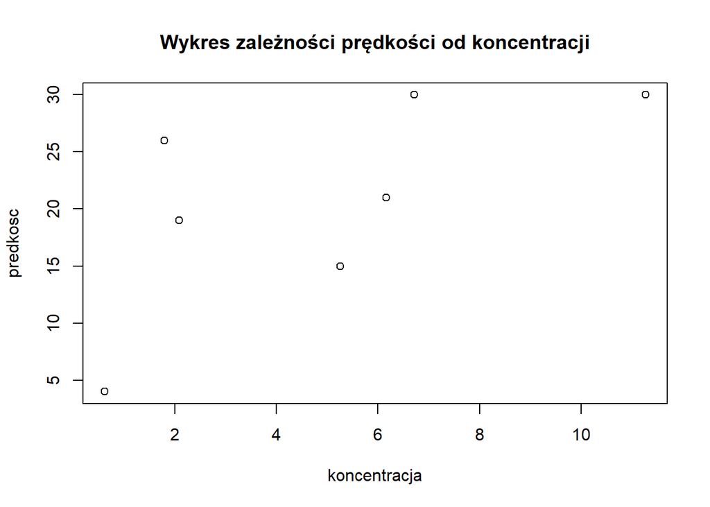

Przedstawiona zależność nie ma charakteru liniowego

### (ii)

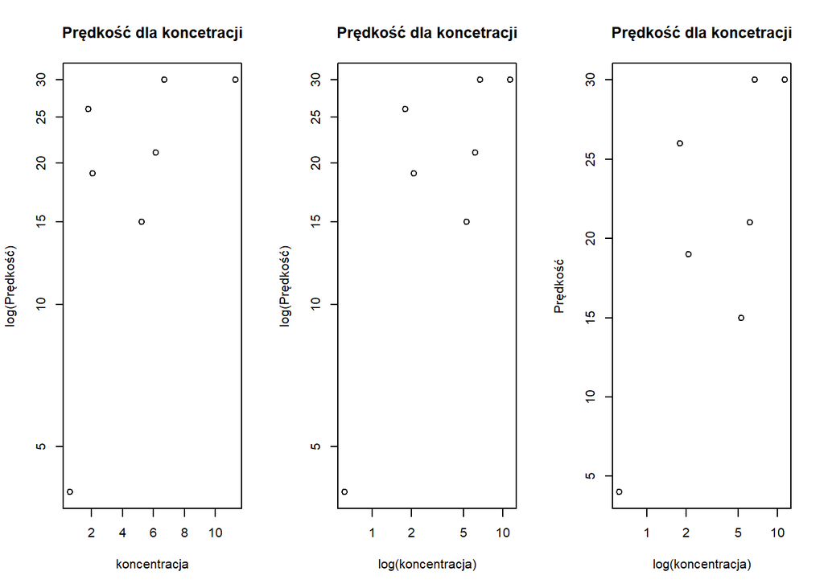

Żadna z powyższych transformacji nie prowadzi do uzyskania liniowego charakteru. Wykres Prędkość~log(koncentracja), najbardziej zbliżony do charakteru liniowego.

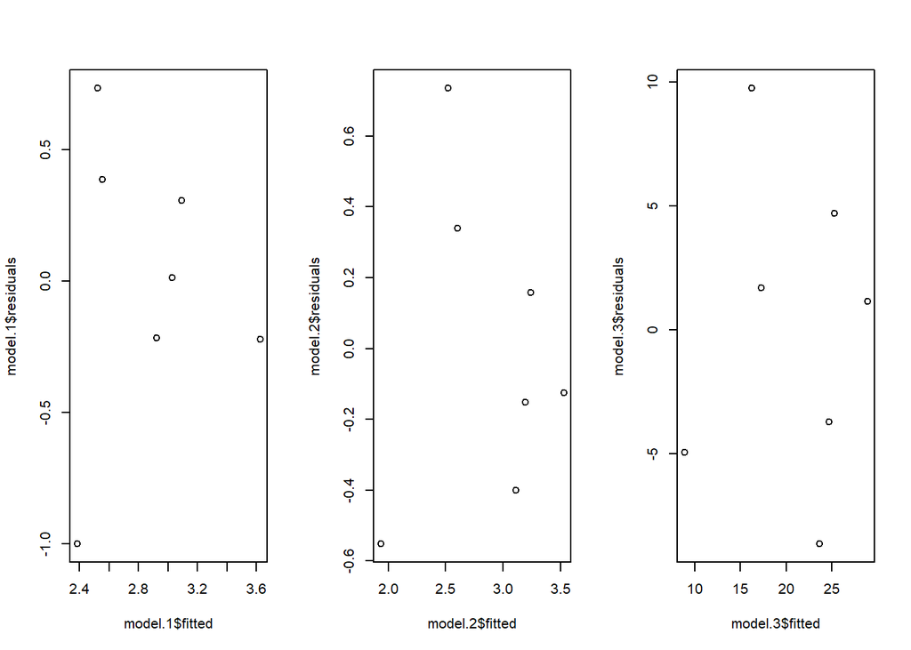

Losowy charakter reszt dla modelu 1, 2 i 3. Dla modelu 2 reszty skupiają sie wokół 0, ten model sugeruje dobre dopasowanie.

### (iii)

```r
model.4 <- lm(predkosc ~ koncentracja + I(koncentracja ^ 2))
summary(model.4)
```

```
##
## Call:
## lm(formula = predkosc ~ koncentracja + I(koncentracja^2))
##
## Residuals:
##       1       2       3       4       5       6       7
## -7.5878  5.0674  0.4279 -8.3738 10.6267 -3.0900  2.9296
##
## Coefficients:
##                   Estimate Std. Error t value Pr(>|t|)
## (Intercept)       10.69371    7.90800   1.352    0.248
## koncentracja       2.77768    3.27419   0.848    0.444
## I(koncentracja^2) -0.09782    0.27230  -0.359    0.738
##
## Residual standard error: 8.435 on 4 degrees of freedom
## Multiple R-squared:  0.4478, Adjusted R-squared:  0.1717
## F-statistic: 1.622 on 2 and 4 DF,  p-value: 0.3049
```

### (iv)

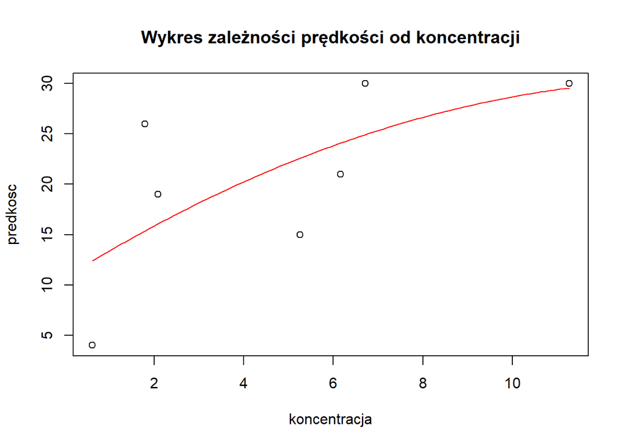

Wszystkie wspołczynniki są nieistotne statystycznie ,współczynnik dopasowania R2 = 0.17

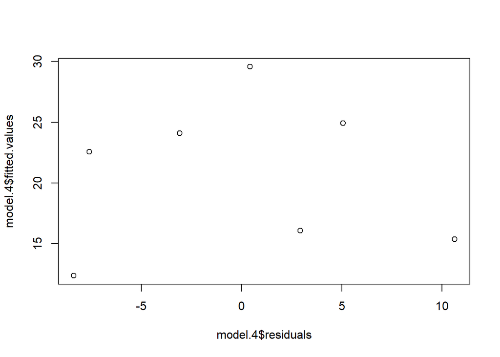

Charakter reszt jest losowy, lecz nie skupiają sie wokół zera. Model nie jest odpowiedni do opisu danych.

### (v)

```r
model.5 <- lm(
  predkosc ~ koncentracja + I(koncentracja ^ 2) + I(koncentracja ^ 3) + I(koncentracja ^ 4) + I(koncentracja ^ 5) + I(koncentracja ^ 6)
)
summary(model.5)
```

```
##
## Call:
## lm(formula = predkosc ~ koncentracja + I(koncentracja^2) + I(koncentracja^3) +
##     I(koncentracja^4) + I(koncentracja^5) + I(koncentracja^6))
##
## Residuals:
## ALL 7 residuals are 0: no residual degrees of freedom!
##
## Coefficients:
##                     Estimate Std. Error t value Pr(>|t|)
## (Intercept)       -120.76838         NA      NA       NA
## koncentracja       325.45467         NA      NA       NA
## I(koncentracja^2) -246.63164         NA      NA       NA
## I(koncentracja^3)   83.77377         NA      NA       NA
## I(koncentracja^4)  -14.25726         NA      NA       NA
## I(koncentracja^5)    1.18499         NA      NA       NA
## I(koncentracja^6)   -0.03785         NA      NA       NA
##
## Residual standard error: NaN on 0 degrees of freedom
## Multiple R-squared:      1,  Adjusted R-squared:    NaN
## F-statistic:   NaN on 6 and 0 DF,  p-value: NA
```

### (vi)

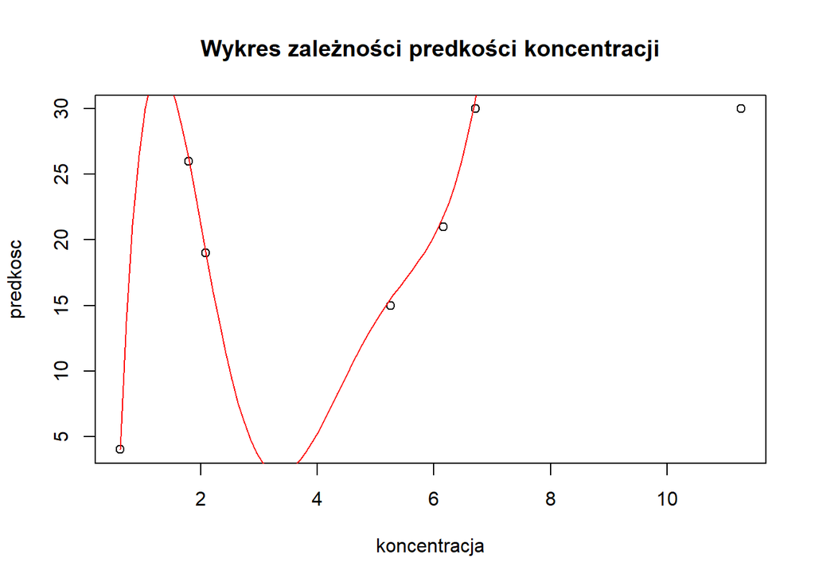

Wspołczynnik dopasowania = 1. Nie jest to model odpowiedni, gdyż dopasowana krzywa jest dopasowana do wszystkich punktów zbioru, nie ma ona wartości predykcyjnej dla przyszłych obserwacji.